# Reproducible Research Course Project 1

This is an analysis of data from a personal activity monitoring device. This device collects data at 5 minute intervals through out the day. The data consists of two months of data from an anonymous individual collected during the months of October and November, 2012 and include the number of steps taken in 5 minute intervals each day.

The data for this analysis can be downloaded from the course web site:

https://d396qusza40orc.cloudfront.net/repdata%2Fdata%2Factivity.zip

The variables included in this dataset are:

steps: Number of steps taking in a 5-minute interval (missing values are coded as NA) date: The date on which the measurement was taken in YYYY-MM-DD format interval: Identifier for the 5-minute interval in which measurement was taken

0 - First let’s load the data and transform date(but very first, please set working directory having data/ directory. data/ dir should have the activity.csv.).

```r
setwd("D:/COURSERA/Reproducible Research/rworkdir/project1")
activity <- read.csv("data/activity.csv")
activity$date <- as.Date(as.character(activity$date))
library(dplyr)
activity <- tbl_df(activity)
```

1 - What is mean total number of steps taken per day?

First find daily totals.

```r
dailysums <- activity %>% group_by(date) %>% summarise(sum(steps, na.rm=TRUE))
```

Check histogram of daily totals.

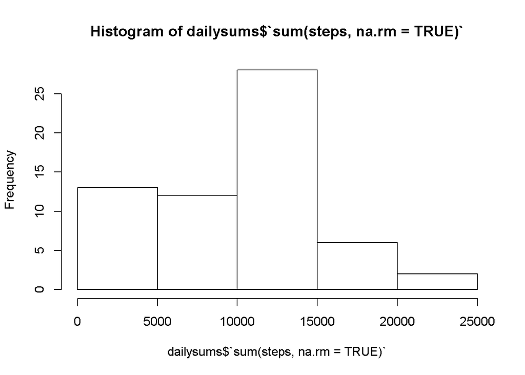

```r
hist(dailysums$`sum(steps, na.rm = TRUE)`)
```

Check the summary of daily totals.

```r
summary(dailysums$`sum(steps, na.rm = TRUE)`)
```

```
##    Min. 1st Qu.  Median    Mean 3rd Qu.    Max.
##       0    6778   10400    9354   12810   21190
```

So the mean of daily totals is 9354 and the median is 10400.

2- What is the avarage daily activity pattern?

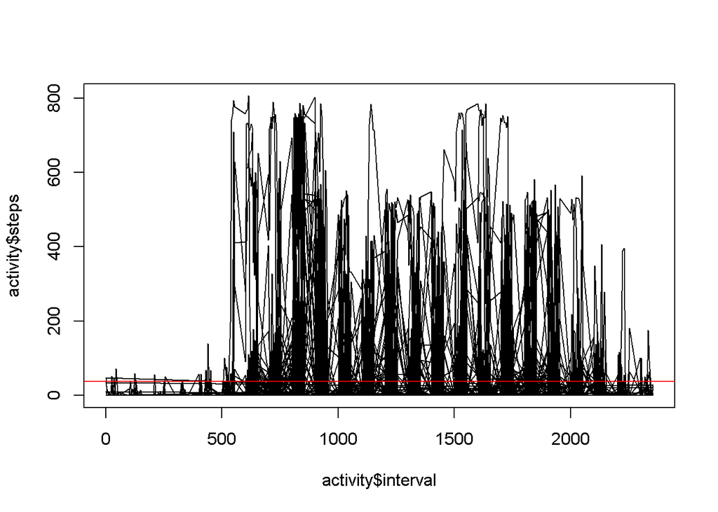

```r
plot(activity$interval,activity$steps,type = "l")
abline(h=mean(activity$steps,na.rm = TRUE), col="red")
```

Which 5-minute interval, on average across all the days in the dataset, contains the maximum number of steps?

```r
activity %>% arrange(desc(steps)) %>% head(1)
```

```
## Source: local data frame [1 x 3]
##
##   steps       date interval
##   (int)     (date)    (int)
## 1   806 2012-11-27      615
```

3- Imputing missing values

The total number of missing values in the dataset

```r
sum(is.na(activity$steps))
```

```
## [1] 2304
```

```r
sum(!is.na(activity$steps))
```

```
## [1] 15264
```

There are 2304 missing values in the dataset.

Let’s fill the missing values with the avarage value of the same interval.

```r
activity <- activity %>% group_by(interval) %>% mutate(round(mean(steps,na.rm=TRUE)))
activity$steps <- ifelse(is.na(activity$steps), activity$`round(mean(steps, na.rm = TRUE))`, activity$steps)
```

New dataset that is equal to the original dataset but with the missing data filled in.

```r
activityn <- select(activity,1:3)
```

First find daily totals.

```r
dailysumsn <- activityn %>% group_by(date) %>% summarise(sum(steps, na.rm=TRUE))
```

Check histogram of daily totals.

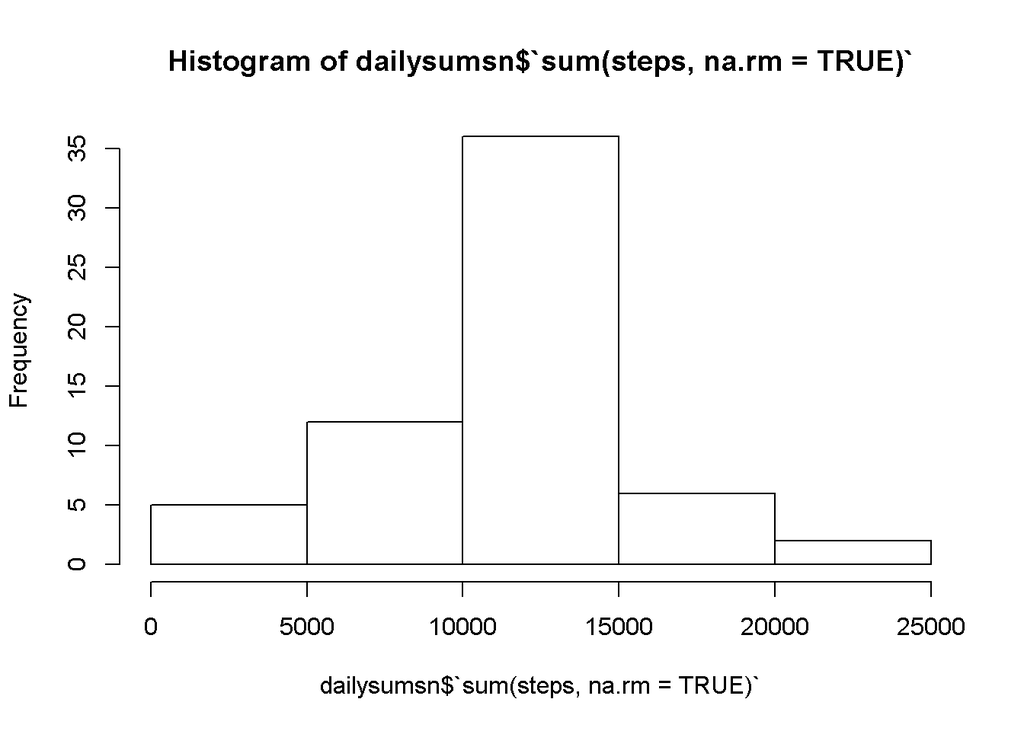

```r
hist(dailysumsn$`sum(steps, na.rm = TRUE)`)
```

Check the summary of daily totals.

```r
summary(dailysumsn$`sum(steps, na.rm = TRUE)`)
```

```
##    Min. 1st Qu.  Median    Mean 3rd Qu.    Max.
##      41    9819   10760   10770   12810   21190
```

Mean changed to 10770 from 9354 and median changed from 10400 to 10760. The skewness of the data has been fixed after imputing the data.

4- Are there differences in activity patterns between weekdays and weekends?

First make a new factor variable to name the date as weekday or weekend. Please do not mind “Pazar” and “Cumartesi” words, these are for sunday and saturday in our locale. no time to fix it. you should change it properly if you want to use the code.

```r
activityn$datem <- ifelse(weekdays(activityn$date) %in% c("Pazar","Cumartesi"), "weekend", "weekday")
activityn$datem <- as.factor(activityn$datem)
```

Plot grouping by weekday & weekend.

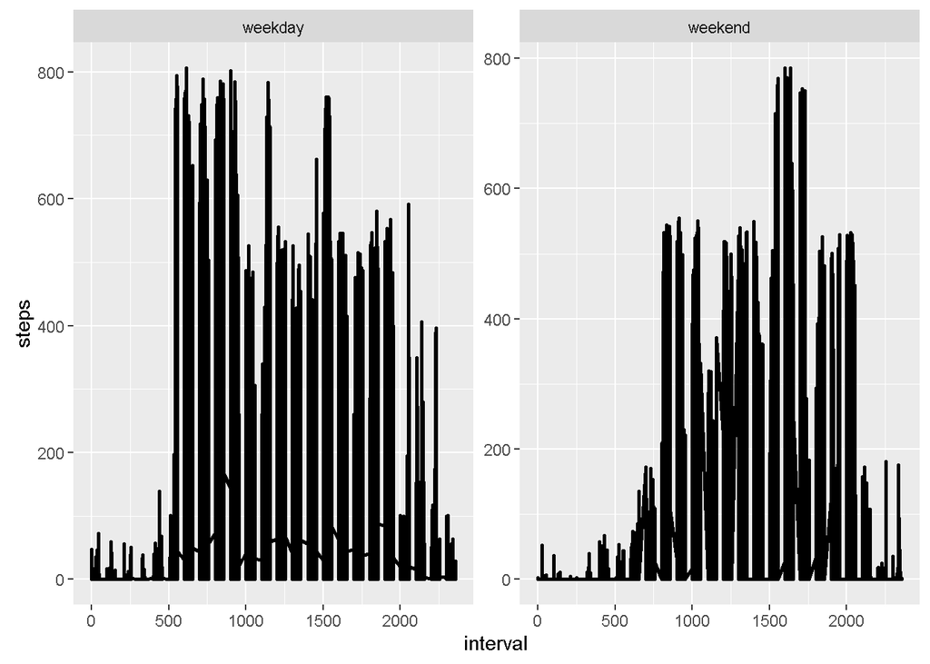

```r
library(ggplot2)
q <- ggplot(data=activityn) + geom_line(aes(x=interval, y=steps), size = 1) + facet_wrap(~ datem, scales = "free_y")
q
```